# Modeling Changes in Bird Occurrence Across Residency Groups in Durham County (2015-2025)

Jonathan Gilman, Nicole Gutkowski, Shaochong Xue

2026-04-24

# Introduction, Motivation, Relevance, Objectives

Anthropogenic environmental change has significantly altered bird diversity and population dynamics, with particularly strong declines observed among migratory species. Long-term studies estimate that North American bird populations have declined by nearly 60% since 1970, underscoring the importance of understanding species-specific trends over time.

These impacts are not uniform across species, as different residency groups (resident, summer migrant, winter migrant) respond differently to environmental pressures. Seasonal variation in occurrence may differ substantially between these groups, making time series approaches especially valuable for capturing both long-term trends and periodic fluctuations.

This study uses Durham County, North Carolina as a case study to analyze long-term trends in bird occurrence across residency types using time series modeling. Three indicator species were selected to represent different residency strategies: Canada Goose (resident), Ruby-throated Hummingbird (summer migrant), and Yellow-rumped Warbler (winter migrant). These species were chosen based on their ecological relevance and the availability of consistent observational data.

# Dataset information

The data for this project are sourced from eBird, a global citizen science database from the Cornell Lab or Ornithology. While this study only analyzes data for three bird species in Durham, NC, the eBird dataset contains data for over 2000 species globally, making it comprehensive resource for ornithology efforts all over the world.

For the intial download of data from eBird, the data request was filtered to our indicator species in Durham, NC. From this, we recieved a dataset with 54246 recorded observations for our three species between February 20, 2002 to January 31, 2026. The dataset included information on species identification, observation details (counts, behavior, breeding), spatial location, time, observer metadata, survey effort, and data quality/validation information.pr

# Data Cleaning (General)

Prior to species-specific analysis, several general cleaning and preparation steps were applied to the full dataset. The raw eBird data was subset to retain only three variables of interest: species identification, observation counts, and date. Although the dataset contains records dating back to 2002, analysis was restricted to January 2015 through January 2026. Data prior to 2015 was highly inconsistent, which we attributed to irregular observer effort rather than true absences of birds, making it unsuitable for reliable time series modeling. Any dates with no recorded observations were filled with zeros, reflecting the assumption that the species was not detected on those days. Data were then aggregated to the monthly level by calculating the mean daily observation count within each month, resulting in a continuous monthly time series for each species with no gaps. Finally, each aggregated dataframe was formatted as a time series object to facilitate downstream modeling and forecasting. Species-specific outlier removal and additional cleaning steps are described within each species’ analysis section below.

# Analysis (Methods and Models)

### Canada Goose Models and Results

For the time series analysis of Canada Goose observation data, I chose to use the monthly data for training and forecasting models. Prior to any modeling, general data exploration and further cleaning were performed.

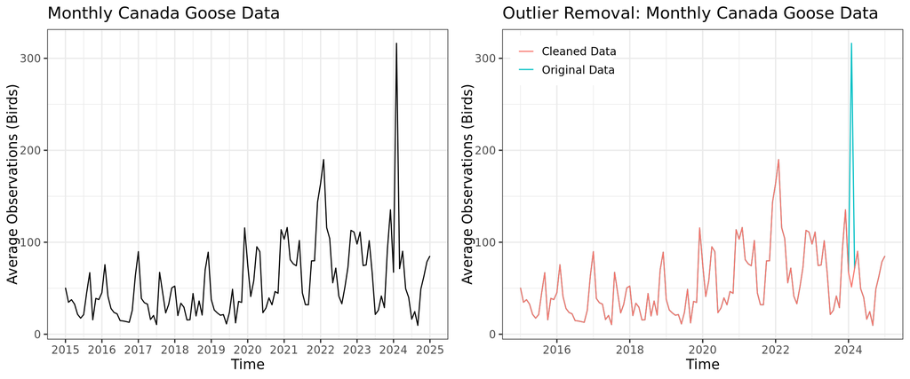

Initial time series plot and cleaning of the monthly Canada Goose Observations Data

Summary Statistics for Cleaned Monthly Goose Observations

| Mean | Median | SD | Min | Max | 1st Quartile | 3rd Quartile |
| --- | --- | --- | --- | --- | --- | --- |
| 53.44 | 41.55 | 35.43 | 9.6 | 189.89 | 25.94 | 75.28 |

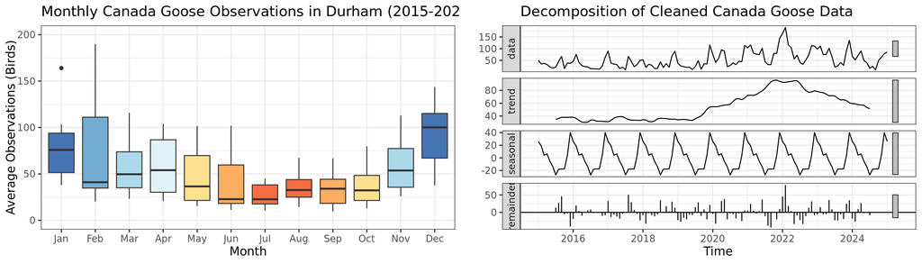

Distribution of Monthly Observations of Canada Geese

From the plot of distributions of monthly observations, the Canada Goose appears to have a slight seasonal pattern. However, consistency in observations year-round support the Canada Goose’s resident species status.

The decomposition of the cleaned series also shows a strong seasonal pattern and trend. However the trend does not appear to have a consistent pattern over the course of the time series.

#### ACF and PACF

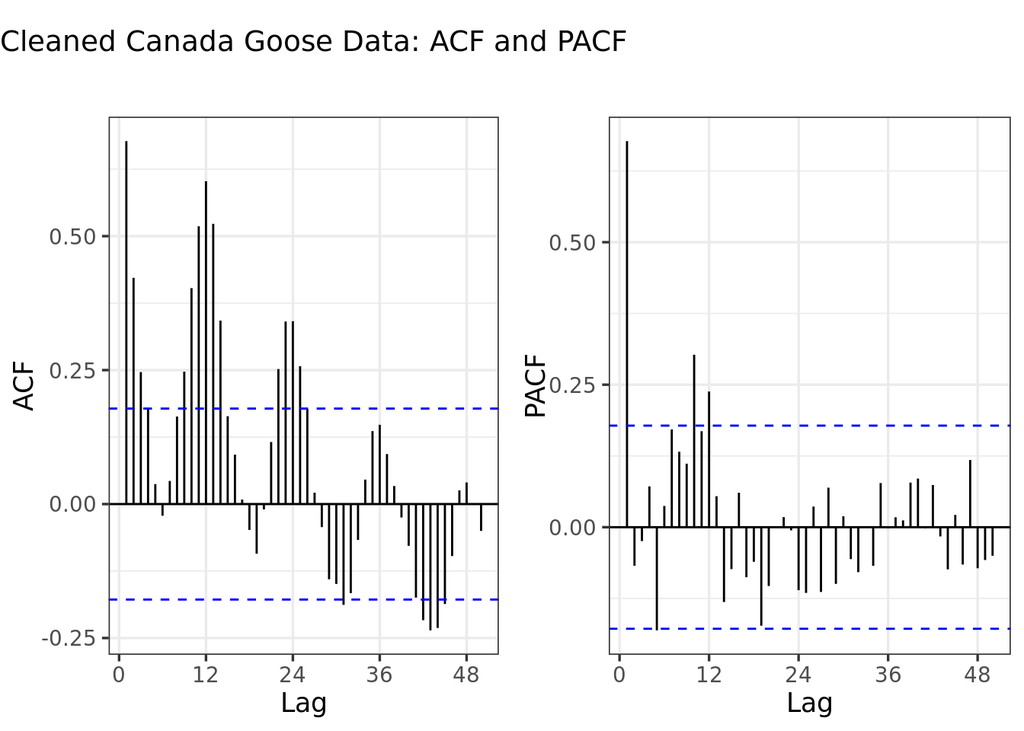

ACF and PACF plots for the cleaned monthly Canada Goose time series

Based on observations from the decomposition of the series and the ACF and PACF, we thought that models accounting for seasonality would be best for the series. The initial models that were chosen were the SARIMA and the Basic Structural Model.

SARIMA

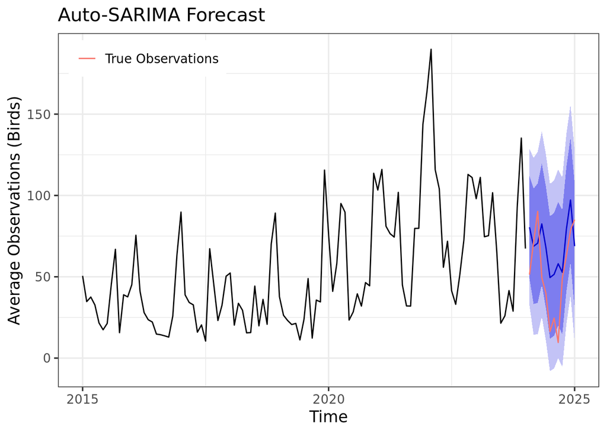

```
##                 ME     RMSE      MAE       MPE     MAPE
## Test set -16.58979 26.10221 22.97642 -85.33543 92.72052
```

#### BSM model

```
##                 ME     RMSE      MAE       MPE     MAPE
## Test set -13.94191 29.06706 24.32307 -90.07795 102.6163
```

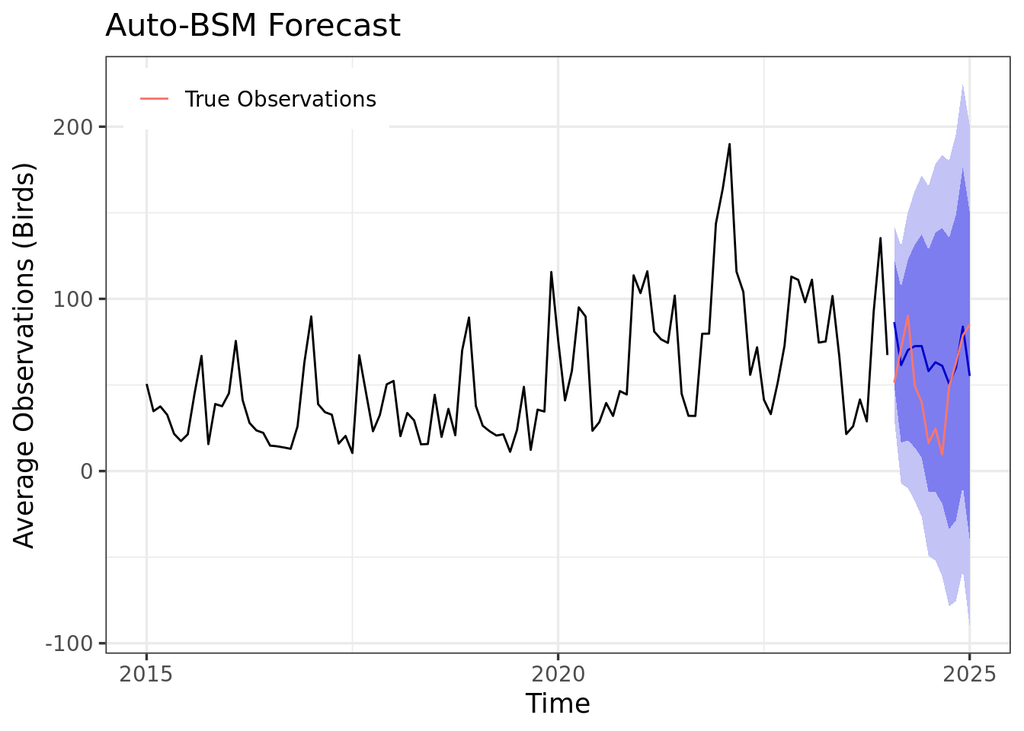

#### Comparison of Models

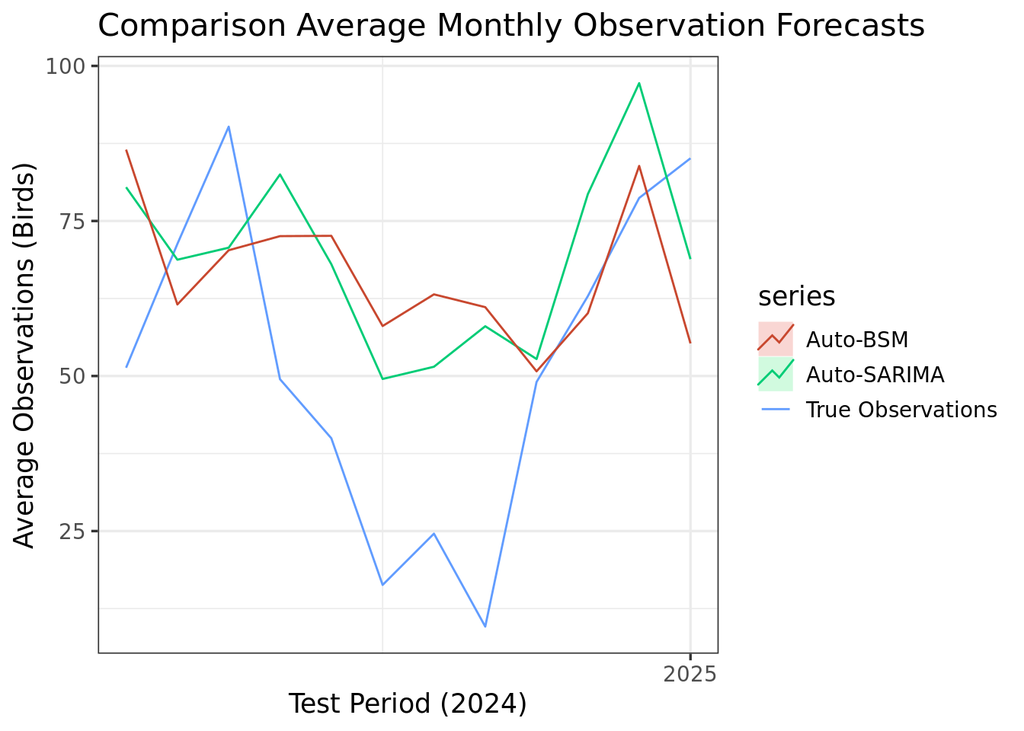

Forecasts for Monthly Canada Goose Observations

|  | ME | RMSE | MAE | MPE | MAPE |
| --- | --- | --- | --- | --- | --- |
| Auto-BSM | -13.94 | 29.07 | 24.32 | -90.08 | 102.62 |
| Auto-SARIMA | -16.59 | 26.10 | 22.98 | -85.34 | 92.72 |

### Warbler Models and Results

The Yellow-rumped Warbler (YRWA) is a common winter migratory species in North Carolina. In this section, we analyze the temporal pattern of YRWA observations and develop time series models to forecast future trends.

We compare modeling results based on observation count and observer ratio. The observer ratio standardizes observation counts and helps control for variation in birding effort over time.

#### Summary Statistics

Summary Statistics for Monthly YRWA Observations and Observer Ratio

| Dataset | Mean | Median | SD | Min | Max | X1st.Quartile | X3rd.Quartile |
| --- | --- | --- | --- | --- | --- | --- | --- |
| Observations | 15.80 | 10.70 | 15.27 | 0 | 53.2 | 0 | 28.42 |
| Observer Ratio | 0.43 | 0.61 | 0.36 | 0 | 0.9 | 0 | 0.77 |

Summary statistics show clear differences between observation count and observer ratio. The mean monthly observation count is 15.80, with a relatively large standard deviation (15.27), indicating high variability across months. In contrast, the observer ratio has a lower mean (0.43) and smaller variability (SD = 0.36), suggesting a more stable relative measure after accounting for observer effort.

Both variables include values close to zero, reflecting months with very low or no observations. The maximum observation count reaches 53.2, while the observer ratio peaks at 0.9, indicating periods of high detection relative to effort.

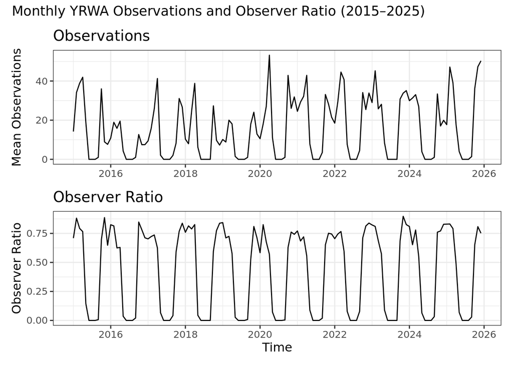

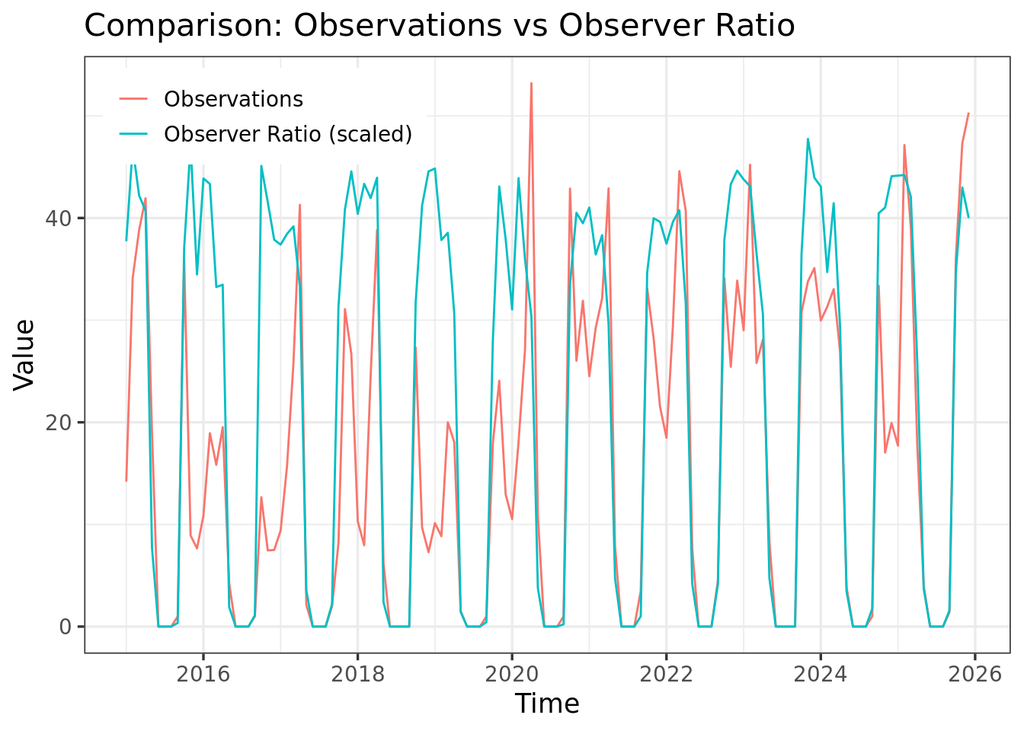

The time series plots reveal strong and consistent seasonal patterns in both observation count and observer ratio. Peaks occur regularly each year, while values drop close to zero during off-season months.

Although the observation count shows greater variability and more pronounced spikes, the observer ratio follows a very similar seasonal pattern, indicating that the temporal dynamics are not solely driven by changes in observer effort.

When comparing observation count with the scaled observer ratio, the two series closely align in terms of timing and overall pattern. However, the observation count exhibits larger fluctuations, while the observer ratio appears smoother and more consistent. This highlights the advantage of the observer ratio in reducing the influence of varying sampling effort.

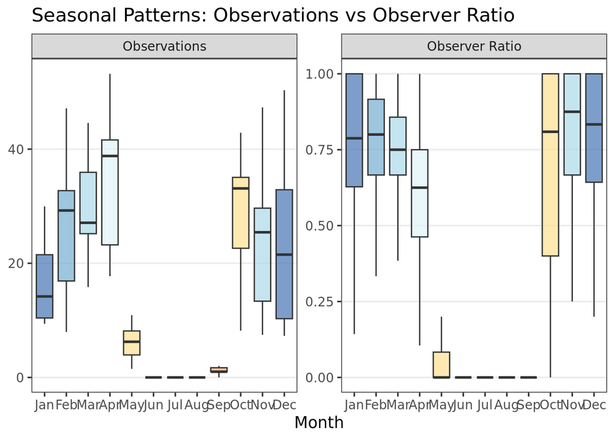

The seasonal boxplots further confirm strong monthly patterns. Observations are highest during April, corresponding to peak migration periods. In contrast, values drop to near zero during summer months (June to August), when the species is largely absent from the region.

The observer ratio shows a nearly identical seasonal structure, with high values concentrated in winter months and minimal activity in summer. This consistency suggests that the observed seasonal pattern reflects true biological behavior rather than sampling bias.

Additionally, variability is highest during peak months, indicating that observation intensity can vary substantially across years during migration periods.

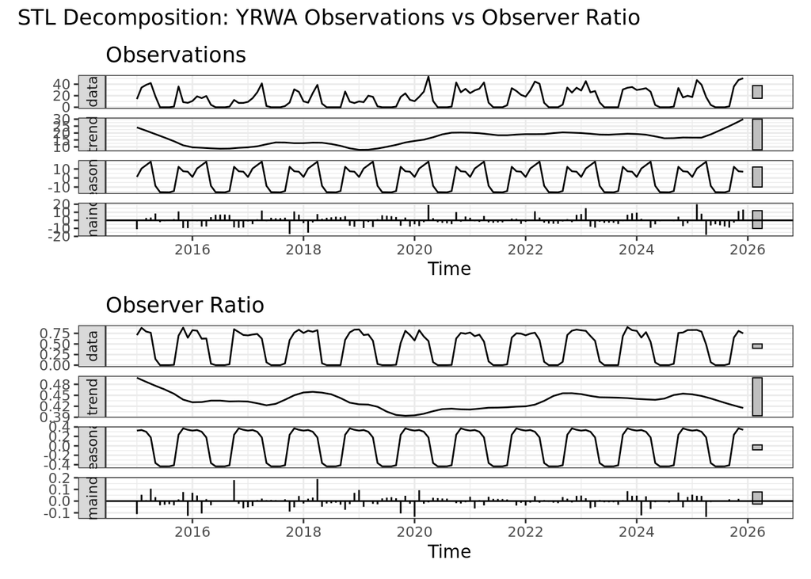

#### ACF and PACF

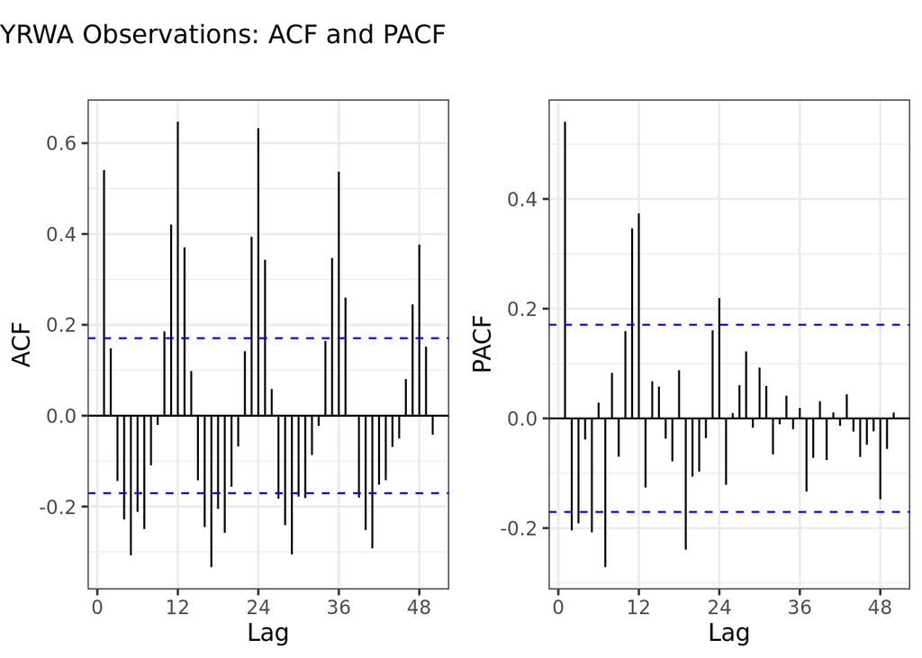

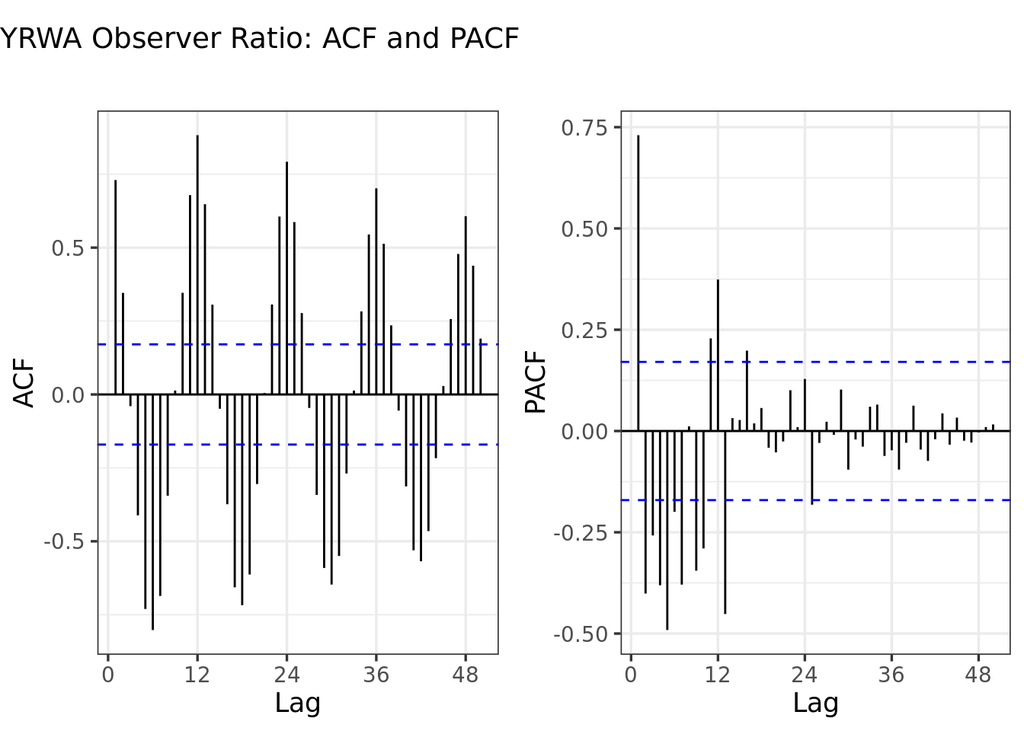

The ACF plots for both observation count and observer ratio show strong and repeated spikes at seasonal lags (e.g., 12, 24, and 36 months), indicating clear annual seasonality in the data. In both cases, autocorrelation decays slowly, suggesting persistent temporal structure rather than random variation.

The PACF plots for both series show a strong spike at lag 1, along with weaker signals at seasonal lags. This indicates the presence of short-term dependence as well as seasonal effects.

Overall, both observation count and observer ratio exhibit similar autocorrelation structures, suggesting that the seasonal pattern is robust and not driven solely by variation in observer effort. These results support the use of seasonal time series models such as SARIMA.

#### YRWA Observation Time Series Modeling and Forecasting

We fit three time series models to the monthly YRWA observation series: a seasonal ARIMA (SARIMA) model, an ARIMA model with Fourier terms, and an exponential smoothing (ETS) model. The SARIMA model captures both short-term dependence and seasonal structure, while the ARIMA + Fourier model provides a flexible way to model smooth seasonal patterns. The ETS model serves as a benchmark based on error, trend, and seasonal components.

To evaluate model performance, we split the time series into a training set (ending in December 2024) and a test set (starting in January 2025). Each model was fitted on the training data and used to generate forecasts for the test period. Model adequacy was assessed using residual diagnostics, and forecasting performance on test set.

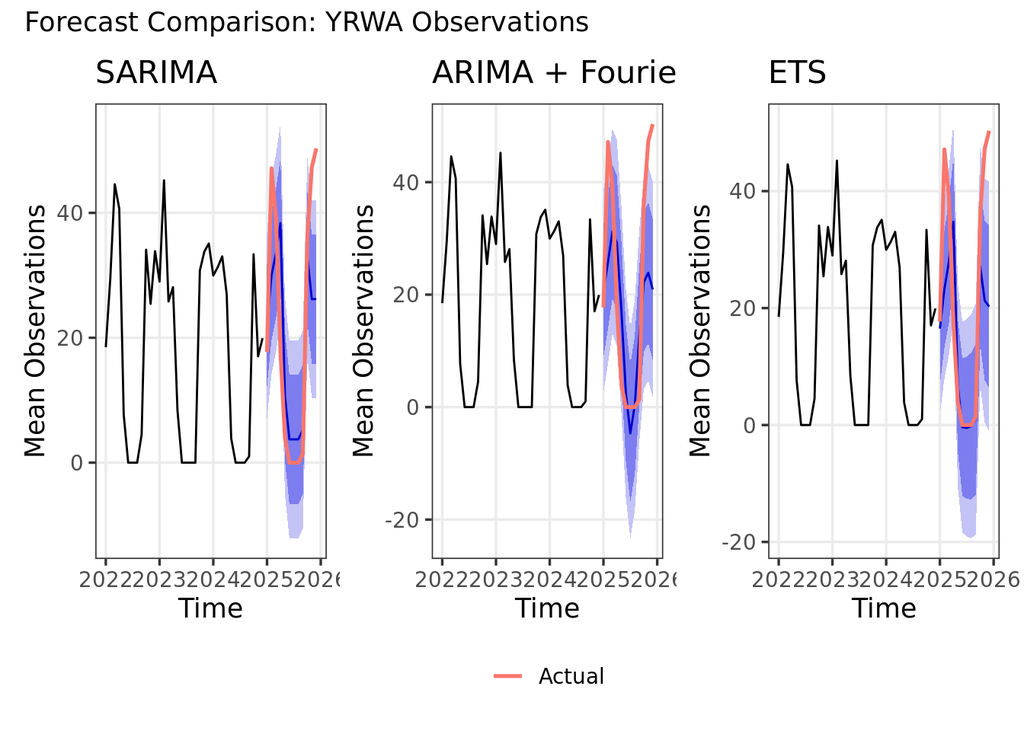

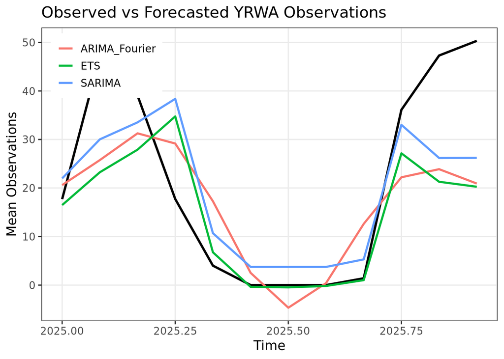

Forecast Accuracy for YRWA Observation Models

| Model | RMSE | MAE | MAPE | MASE |
| --- | --- | --- | --- | --- |
| SARIMA | 12.604 | 9.807 | Inf | 1.550 |
| ARIMA + Fourier | 14.702 | 11.858 | Inf | 1.874 |
| ETS | 14.878 | 10.210 | Inf | 1.614 |

The forecast accuracy results show that the SARIMA model performs best among the three models, with the lowest RMSE (12.604), MAE (9.807), and MASE (1.550). In comparison, the ARIMA + Fourier and ETS models both have higher error values, indicating weaker out-of-sample performance. Although MAPE is infinite for all models due to zero values in the test set, the relative ranking based on other metrics clearly favors the SARIMA model.

```
## Series: YRWA_obs_ts
## ARIMA(1,0,0)(2,1,0)[12]
##
## Coefficients:
##          ar1     sar1     sar2
##       0.4172  -0.7753  -0.3243
## s.e.  0.0851   0.1006   0.1033
##
## sigma^2 = 62.93:  log likelihood = -421.22
## AIC=850.45   AICc=850.8   BIC=861.6
##
## Training set error measures:
##                     ME    RMSE      MAE MPE MAPE      MASE       ACF1
## Training set 0.5439154 7.46864 4.796679 NaN  Inf 0.7280814 0.01092545
```

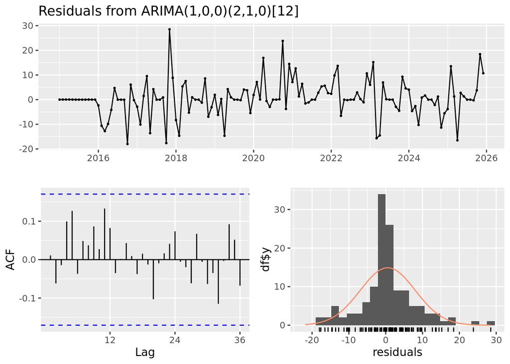

```
##
##  Ljung-Box test
##
## data:  Residuals from ARIMA(1,0,0)(2,1,0)[12]
## Q* = 13.327, df = 21, p-value = 0.8967
##
## Model df: 3.   Total lags used: 24
```

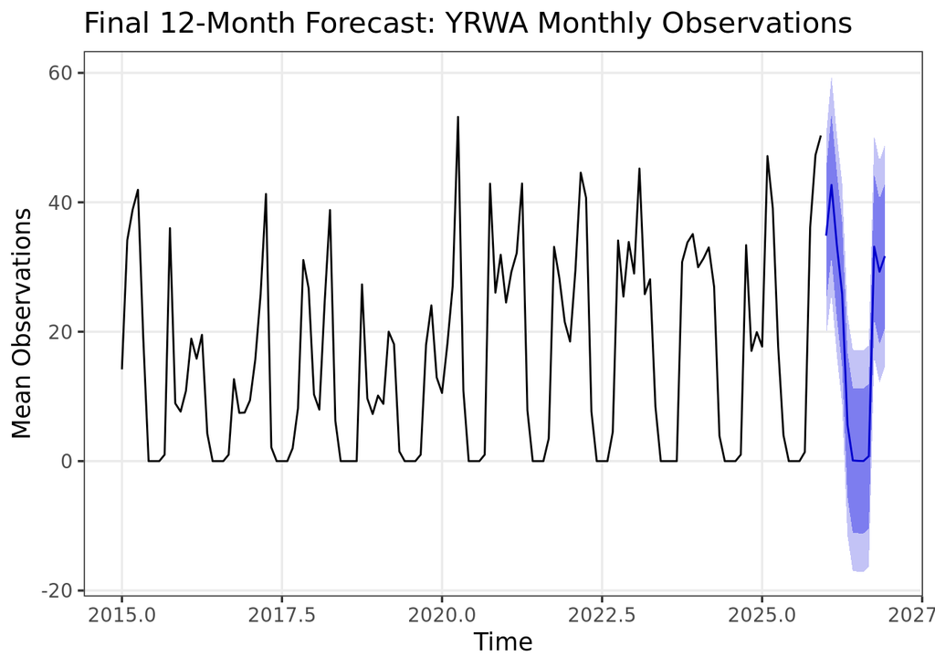

The selected SARIMA model (ARIMA(1,0,0)(2,1,0)[12]) captures both short-term dependence and strong seasonal structure in the data. Residual diagnostics indicate that the model adequately accounts for temporal patterns, as the residuals fluctuate around zero and show no clear systematic structure. The ACF of residuals does not display significant autocorrelation, and the Ljung–Box test (p-value = 0.8967) suggests that the residuals are not significantly different from white noise. This indicates that the model provides a good fit to the observed time series.

#### YRWA Observer Ratio Time Series Modeling and Forecasting

We applied a similar modeling framework to the YRWA observer ratio time series as used for the observation data. Specifically, we fitted SARIMA, ARIMA with Fourier terms, and ETS models, and evaluated their performance using a train–test split and forecasting.

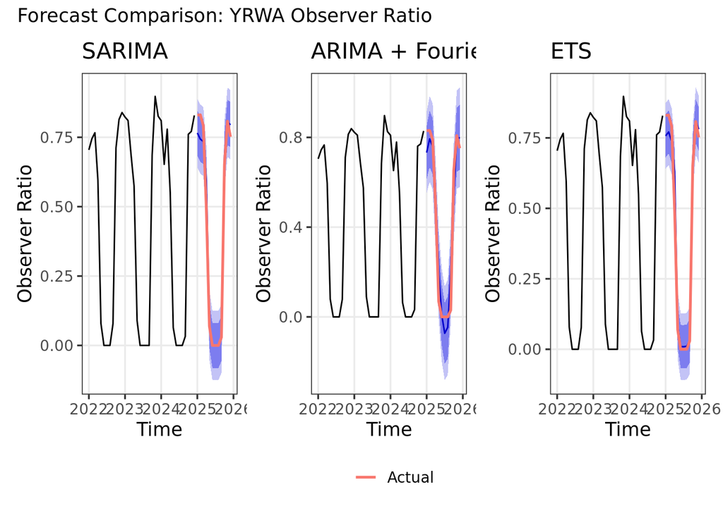

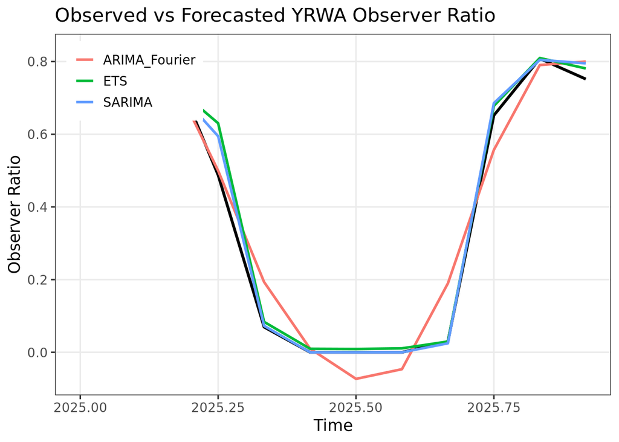

The forecast results for the observer ratio show that all three models capture the strong seasonal pattern, with similar timing of peaks and troughs. Compared to the observation count, the forecasts appear more stable and consistent across models, reflecting the effect of standardizing for observer effort. Among the models, SARIMA and ETS align more closely with the observed values, while the ARIMA + Fourier model shows slightly larger deviations, particularly during low-value periods. Overall, the differences between models are smaller than in the observation-based results, suggesting that the observer ratio provides a smoother and more stable signal for forecasting.

Forecast Accuracy for YRWA Observer Ratio Models

| Model | RMSE | MAE | MAPE | MASE |
| --- | --- | --- | --- | --- |
| SARIMA | 0.050 | 0.034 | 8.833 | 0.649 |
| ARIMA + Fourier | 0.078 | 0.063 | Inf | 1.212 |
| ETS | 0.053 | 0.036 | Inf | 0.690 |

```
## Series: YRWA_ratio_ts
## ARIMA(0,0,0)(0,1,1)[12]
##
## Coefficients:
##          sma1
##       -0.7572
## s.e.   0.0963
##
## sigma^2 = 0.00387:  log likelihood = 158.4
## AIC=-312.79   AICc=-312.69   BIC=-307.22
##
## Training set error measures:
##                        ME      RMSE        MAE  MPE MAPE      MASE       ACF1
## Training set -0.005076871 0.0590689 0.03904748 -Inf  Inf 0.7676367 0.08724649
```

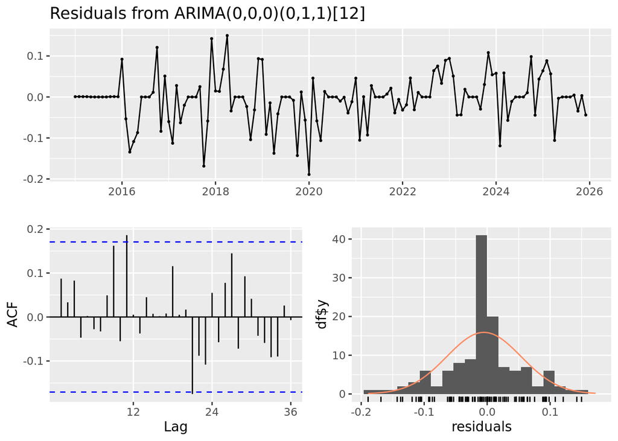

```
##
##  Ljung-Box test
##
## data:  Residuals from ARIMA(0,0,0)(0,1,1)[12]
## Q* = 23.482, df = 23, p-value = 0.4329
##
## Model df: 1.   Total lags used: 24
```

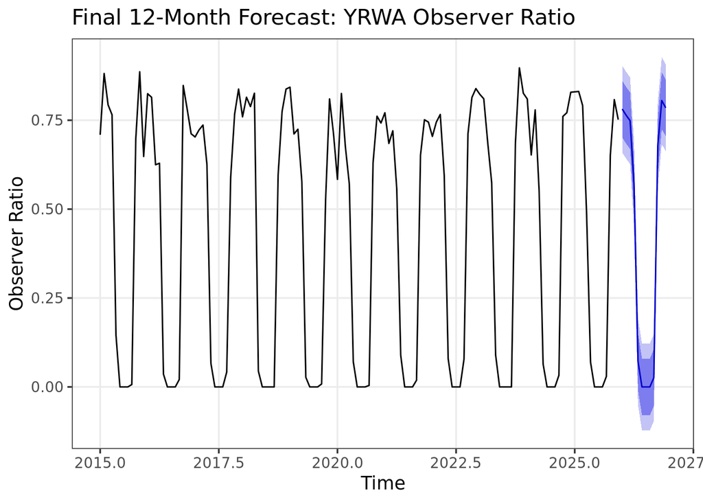

The forecast accuracy results show that the SARIMA model performs best for the observer ratio series, with the lowest RMSE, MAE, and MASE. This result is consistent with the findings for the observation data. The ETS model performs slightly worse but remains comparable, while the ARIMA + Fourier model shows larger errors.

The selected SARIMA model captures the strong seasonal pattern in the observer ratio series, and residual diagnostics indicate a good fit with no significant remaining autocorrelation. The final 12-month forecast shows a clear continuation of the annual cycle, with smoother and more stable patterns than those observed in the raw observation data. Although uncertainty increases over time, the seasonal structure remains consistent, indicating that future trends are likely to follow similar dynamics.

### Ruby-throated Hummingbird Models and Results

For the Ruby-throated Hummingbird analysis, I used monthly data from 2015-2025. The Ruby-throated Hummingbird is a summer migrant that breeds in Durham and migrates south for winter. Prior to modeling, I performed data exploration and cleaning.

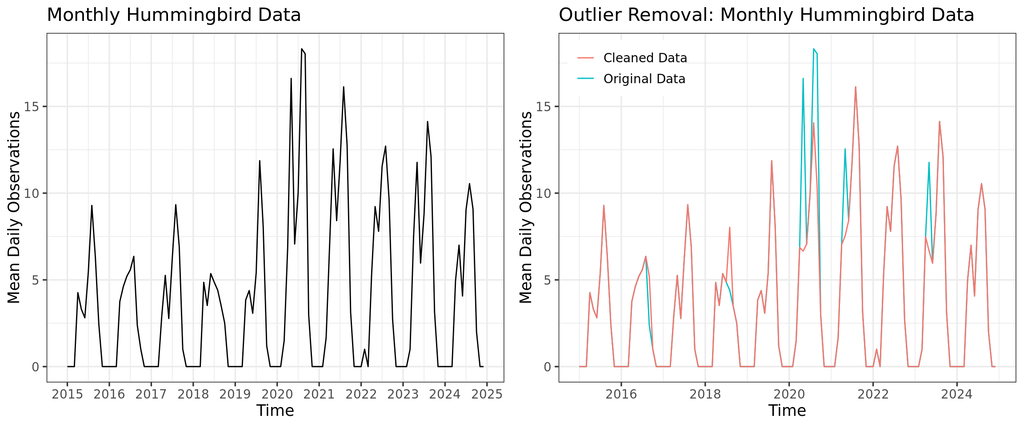

Initial time series and outlier removal for monthly Ruby-throated Hummingbird data

After cleaning, summary statistics were calculated. The data shows strong seasonal variation with observations concentrated in summer months and near-zero in winter when hummingbirds migrate south.

Summary Statistics for Cleaned Monthly Hummingbird Observations

| Mean | Median | SD | Min | Max | 1st Quartile | 3rd Quartile |
| --- | --- | --- | --- | --- | --- | --- |
| 3.87 | 2.96 | 4.15 | 0 | 16.13 | 0 | 6.72 |

To visualize the seasonal pattern, I plotted monthly distributions and decomposed the series.

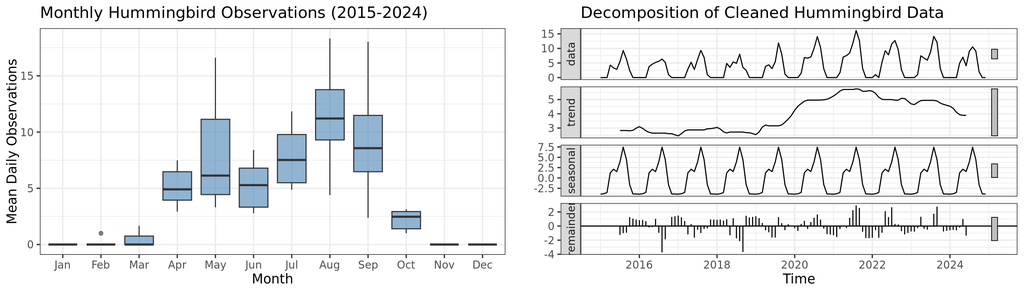

Monthly distributions and decomposition of Ruby-throated Hummingbird time series

#### ACF and PACF

The ACF and PACF were plotted for initial modeling considerations.

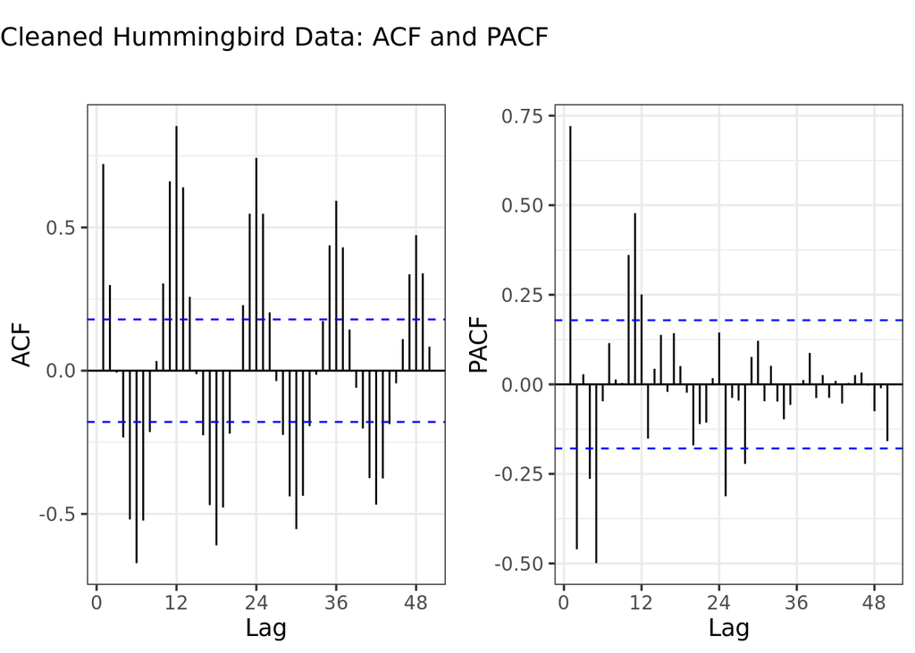

ACF and PACF for the cleaned monthly Ruby-throated Hummingbird series

```
## ndiffs: 0
```

```
## nsdiffs: 1
```

The functions suggested d=0 and D=1. Based on the strong seasonality, I used SARIMA models.

#### Model Fitting

I fit several SARIMA models manually based on the ACF/PACF, then compared to auto.arima().

AIC Comparison for SARIMA Models

| Model | AIC |
| --- | --- |
| ARIMA(1,0,1)(1,1,0)[12] | 368.42 |
| ARIMA(0,0,1)(1,1,0)[12] | 387.33 |
| ARIMA(1,0,0)(1,1,0)[12] | 368.54 |
| Auto-SARIMA | 366.53 |

Auto.arima selected ARIMA(2,0,1)(1,1,0)[12] with the lowest AIC of 366.53.

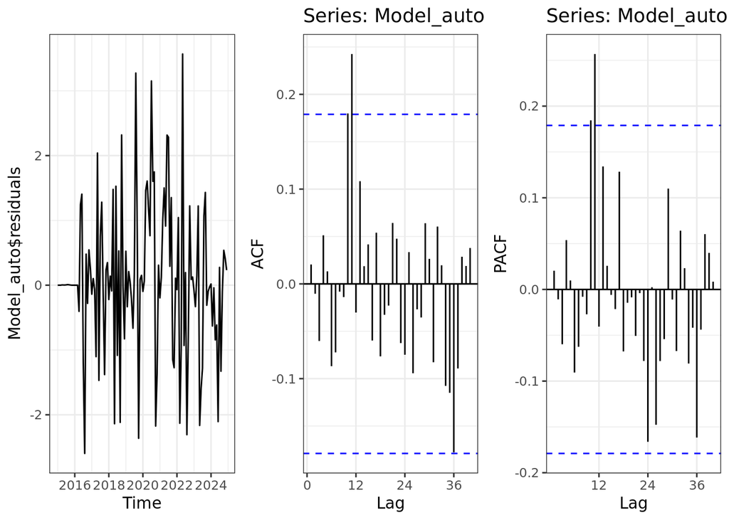

Residual diagnostics for selected SARIMA model

#### Forecasting

I forecast 2025 using SARIMA and seasonal naive as a benchmark.

[output not shown]

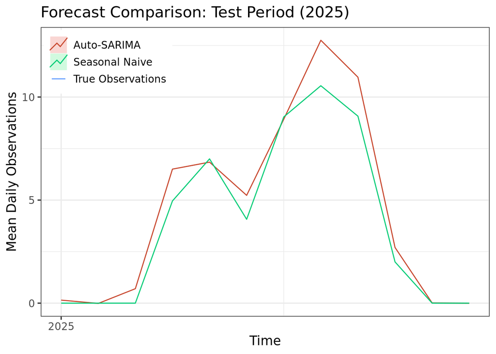

Forecast comparison for 2025 Ruby-throated Hummingbird observations

Both models capture the seasonal pattern. To check accuracy:

Forecast Accuracy for Monthly Ruby-throated Hummingbird Observations

[output not shown]

A known limitation of citizen science data is that observation counts reflect both bird abundance and observer effort. Our above analysis of Yellow-rumped Warbler controlled for this by modeling observer ratio (proportion of observers detecting the species) and found similar seasonal patterns in both metrics, suggesting the trends are ecologically meaningful rather than artifacts of sampling effort. The consistent seasonal pattern observed in hummingbird data likely reflects true migration timing rather than observer bias.

# Summary and Conclusions

This project analyzed time series data from three bird species observed in Durham, NC — the Canada Goose, the Yellow-rumped Warbler (YRWA), and the Ruby-throated Hummingbird — spanning 2015 to 2025. For each species, we explored seasonal structure, fit multiple forecasting models, and evaluated out-of-sample performance. Several consistent findings emerged across all three analyses.

## Model Performance

**Yellow-rumped Warbler:** SARIMA ARIMA(1,0,0)(2,1,0)[12] performed best with RMSE 12.60, MAE 9.81, and MASE 1.55, outperforming both the ARIMA + Fourier and ETS models. All three models captured the timing of seasonal peaks and troughs but differed in their accuracy of magnitude.

## Observer Effort

One issue with citizen science data is that more observations could mean more birds or just more people birding. The warbler analysis checked this by comparing raw counts to observer ratio (how many observers saw the species). Both showed the same seasonal patterns, which suggests we’re seeing real bird patterns and not just sampling bias.

We only analyzed observation counts for goose and hummingbird, but the consistent patterns across species and the warbler validation suggest the trends are real.

## Main Takeaways

All three species showed clear seasonal patterns that matched their life histories - year-round with variation (goose), summer only (hummingbird), winter only (warbler). Simple models worked well when patterns were stable year-to-year, while SARIMA was better for more variable species. The strong seasonal signals show that long-term eBird data is useful for tracking bird phenology despite the observer effort limitations.

Overall, this project demonstrates that time series methods, particularly SARIMA, provide a practical and interpretable framework for modeling avian observation data. The strong seasonal patterns present in all three species make them well-suited to seasonal time series approaches, and the forecasting results suggest these methods can meaningfully capture the temporal dynamics of bird populations in the Durham region.